# Data Open Lecture: An Introduction of R

# 3.2 Plots for Different Variable Types

# Univariate Plot (1): Discrete variable

- Bar plot with geom_bar()

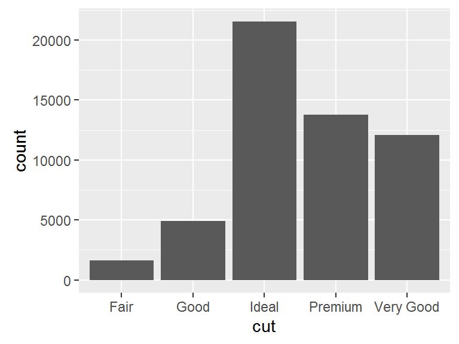

```r
ggplot(data, aes(x = cut)) + geom_bar()
```

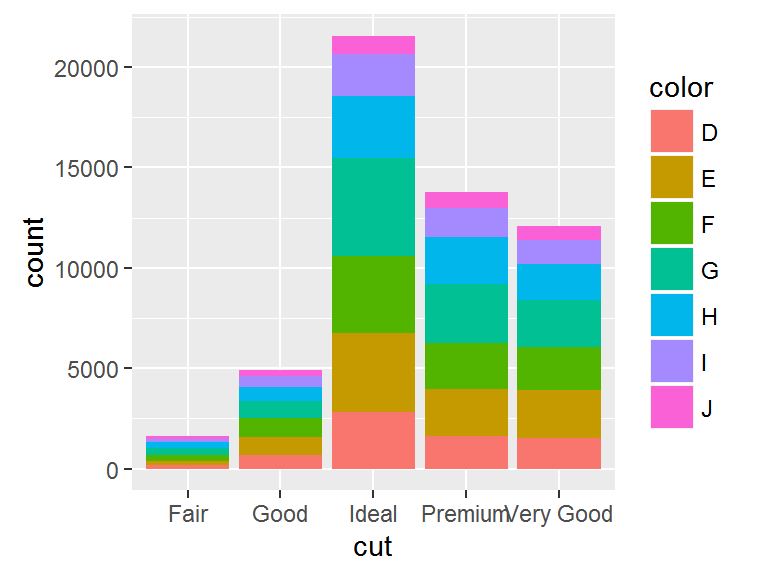

```r
ggplot(data, aes(x = cut)) + geom_bar(aes(fill = color))
```

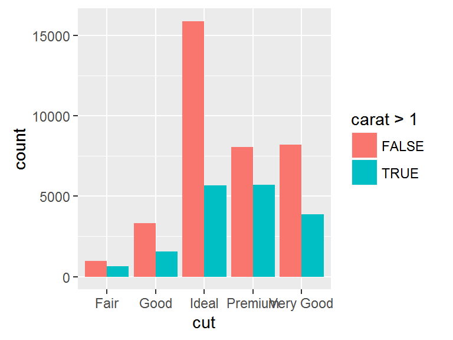

```r
ggplot(data, aes(x = cut)) + geom_bar(aes(fill = carat > 1), position=position_dodge())
```

- Dot plot with geom_dotplot()

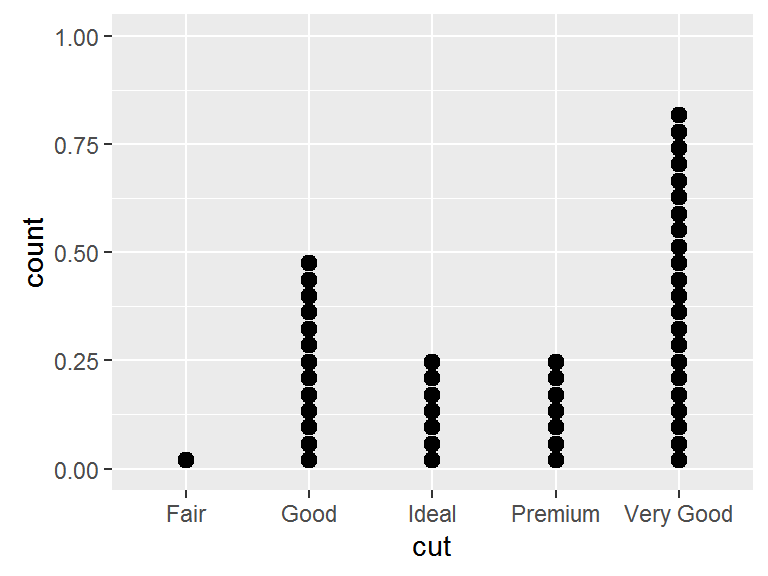

```r
ggplot(data[1:50,], aes(x = cut)) + geom_dotplot()
```

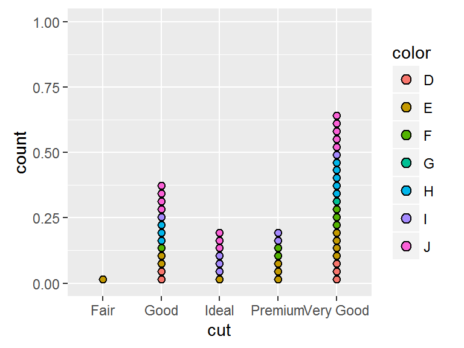

```r
ggplot(data[1:50,], aes(x = cut)) + geom_dotplot(aes(fill = color), stackgroups = TRUE)
```

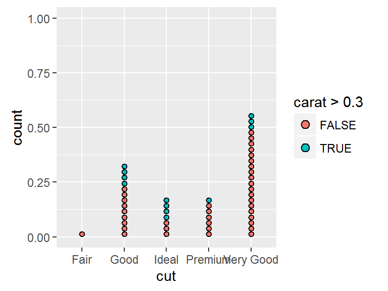

```r
ggplot(data[1:50,], aes(x = cut)) + geom_dotplot(aes(fill = carat > 0.3), stackgroups = TRUE)
```

# Univariate Plot (2): Continuous variable

- Histogram and density plot

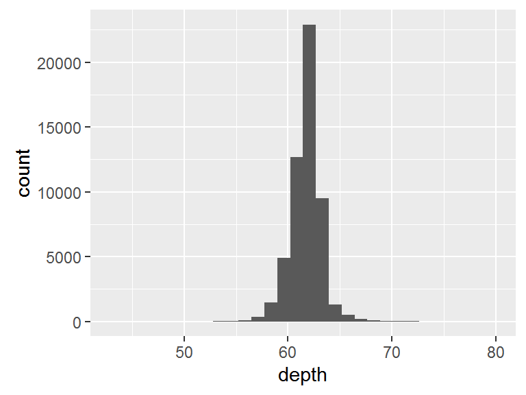

```r
ggplot(data, aes(x = depth)) + geom_histogram()
```

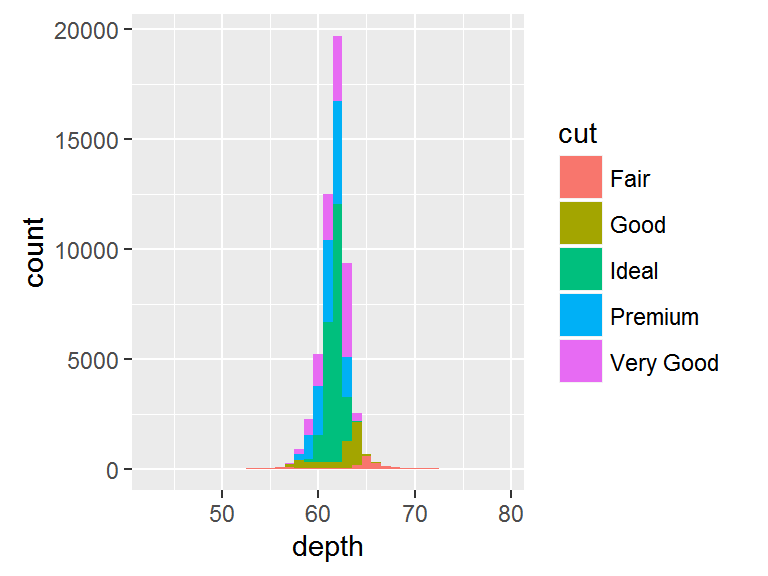

```r
ggplot(data, aes(x = depth)) + geom_histogram(aes(fill = cut), binwidth = 1)
```

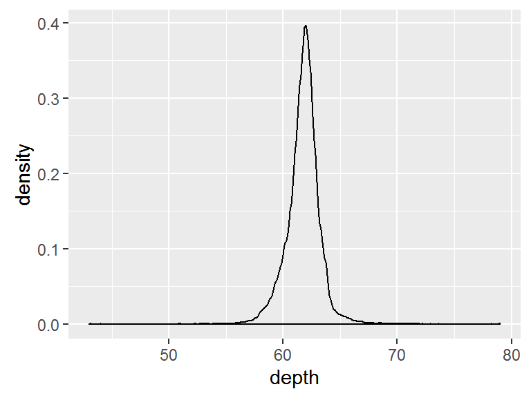

```r
ggplot(data, aes(x = depth)) + geom_density()
```

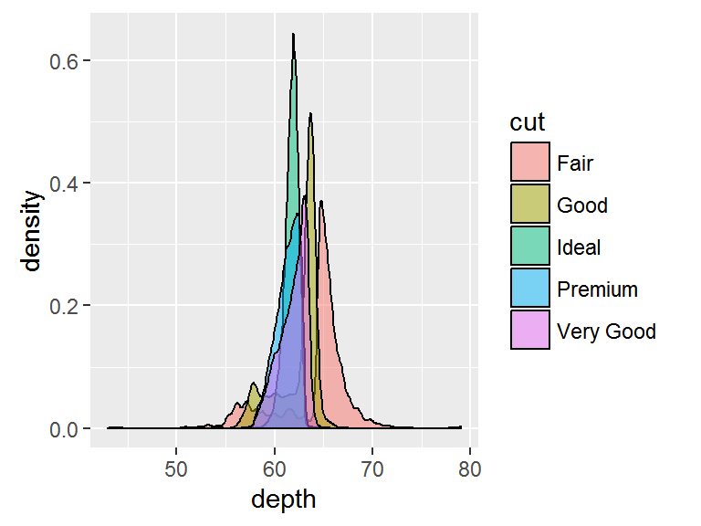

```r
ggplot(data, aes(x = depth)) + geom_density(aes(fill = cut), alpha = 0.5)
```

- Empirical cdf plot and quantile-quantile plot

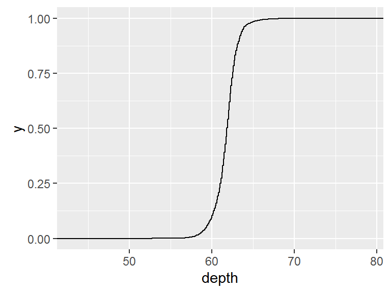

```r
ggplot(data, aes(x = depth)) + stat_ecdf()
```

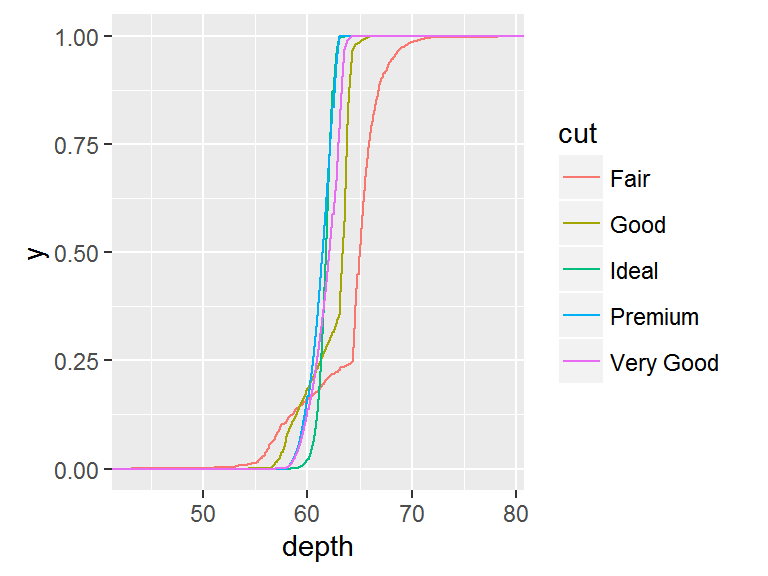

```r
ggplot(data, aes(x = depth)) + stat_ecdf(aes(color = cut))
```

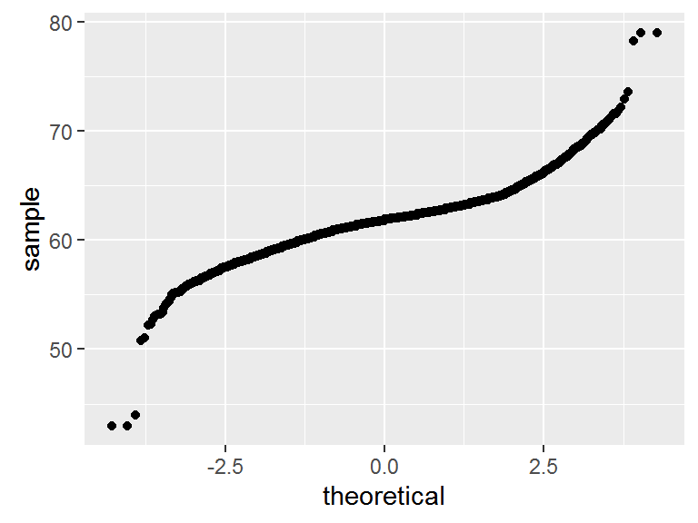

```r
ggplot(data, aes(sample = depth)) + stat_qq()
```

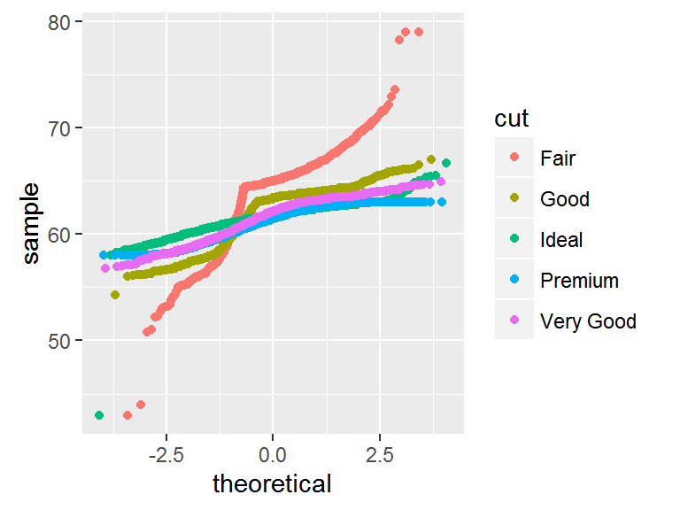

```r
ggplot(data, aes(sample = depth)) + stat_qq(aes(color = cut))
```

# Univariate Plot (3): Function

- We can plot univariable function using ggplot

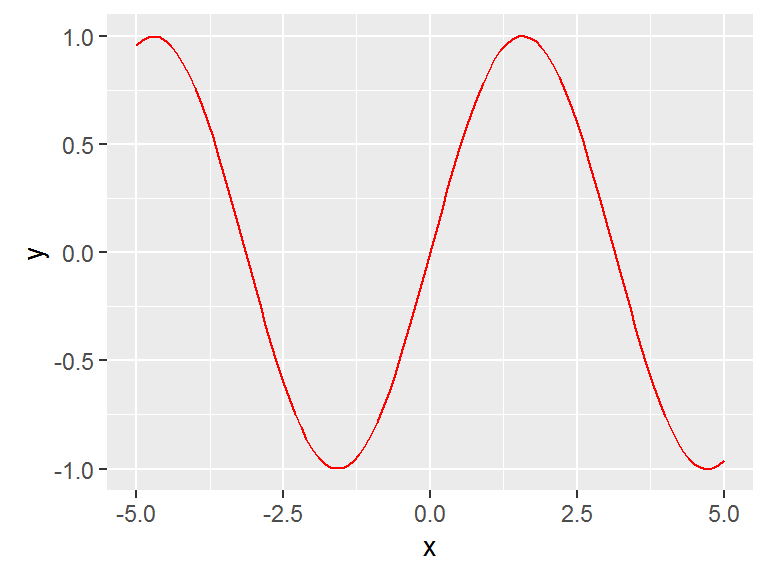

```r
ggplot(data.frame(x = c(-5, 5)), aes(x = x)) + stat_function(fun = sin, color = "red")
```

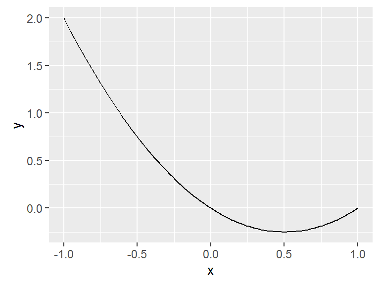

```r
ggplot(data.frame(x = c(-1, 1)), aes(x = x)) + stat_function(fun = function(x){return(x^2 - x)})
```

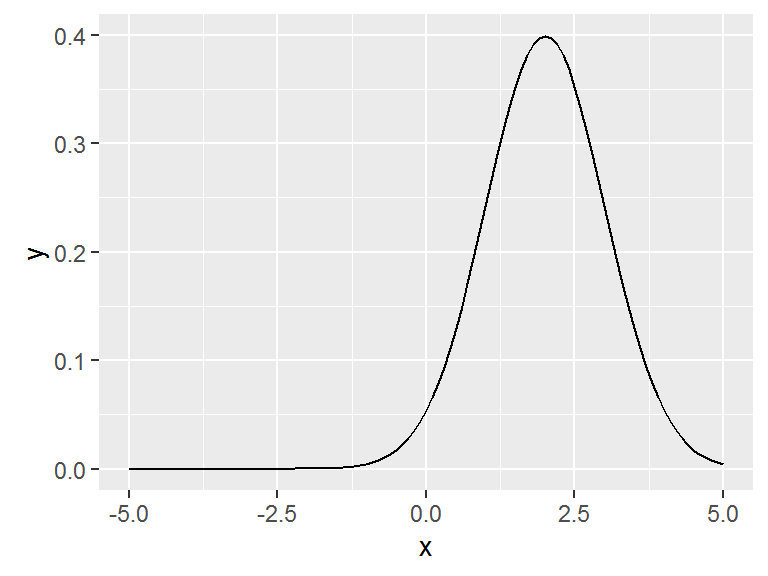

```r
ggplot(data.frame(x = c(-5, 5)), aes(x = x)) + stat_function(fun = dnorm, args = list(mean = 2))
```

# Bivariate Plot (1): Two Discrete variables

- Take roughly count with geom_bin2d() and geom_jitter()

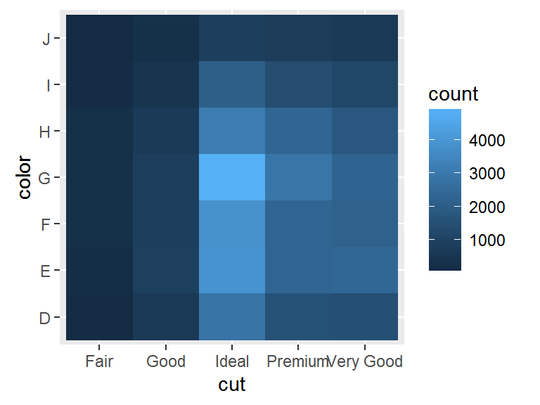

```r
ggplot(data, aes(x = cut, y = color)) + geom_bin2d()
```

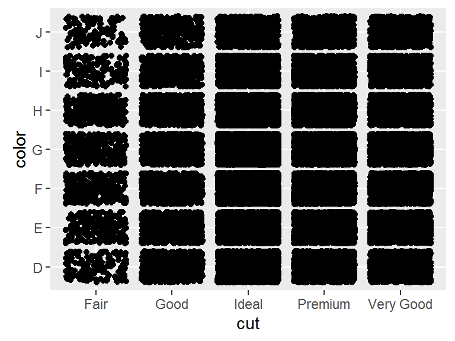

```r
ggplot(data, aes(x = cut, y = color)) + geom_jitter()
```

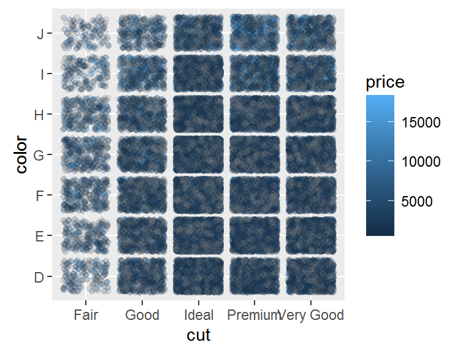

```r
ggplot(data, aes(x = cut, y = color)) + geom_jitter(aes(color = price), alpha = 0.2)
```

# Bivariate Plot (2): A Continuous and A Discrete

- Box plot and violin plot

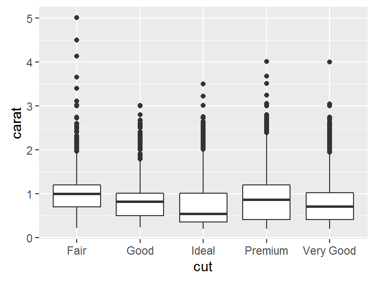

```r
ggplot(data, aes(x = cut, y = carat)) + geom_boxplot()
```

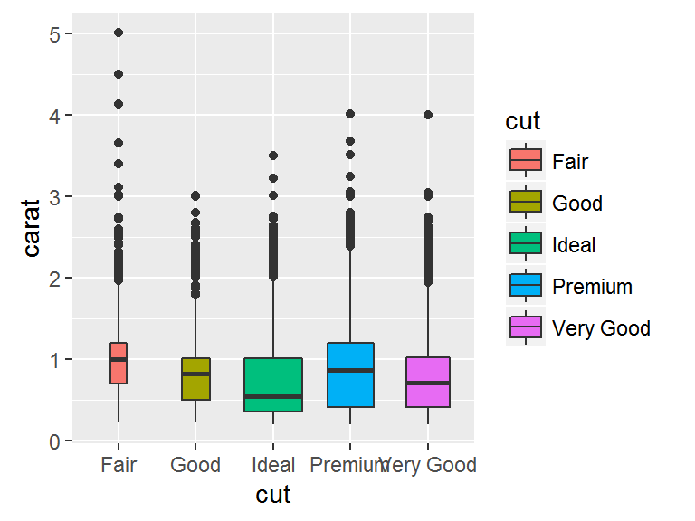

```r
ggplot(data, aes(x = cut, y = carat)) + geom_boxplot(aes(fill = cut), varwidth = TRUE)
```

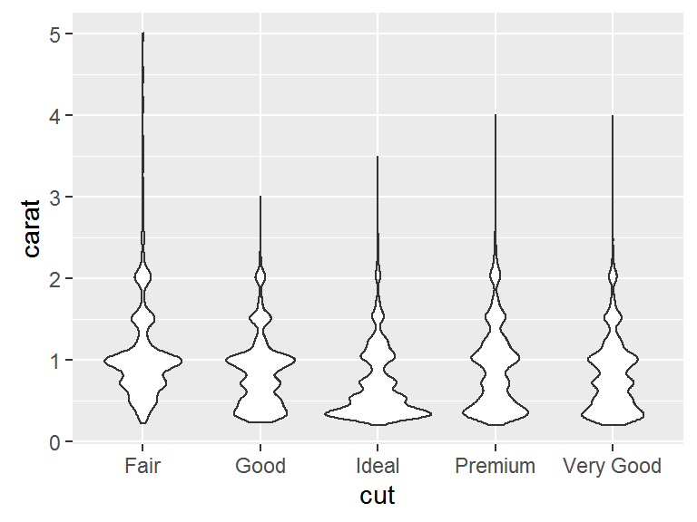

```r
ggplot(data, aes(x = cut, y = carat)) + geom_violin()
```

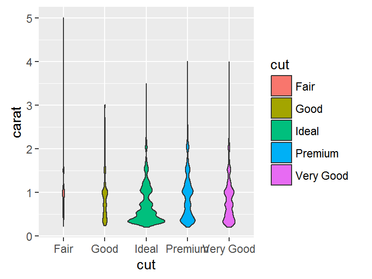

```r
ggplot(data, aes(x = cut, y = carat)) + geom_violin(aes(fill = cut), scale = "count")
```

- 2-D heatmap and jitter plot

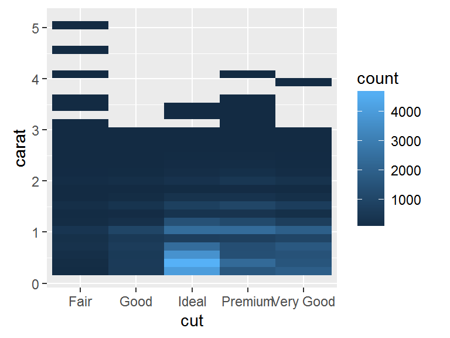

```r
ggplot(data, aes(x = cut, y = carat)) + geom_bin2d()
```

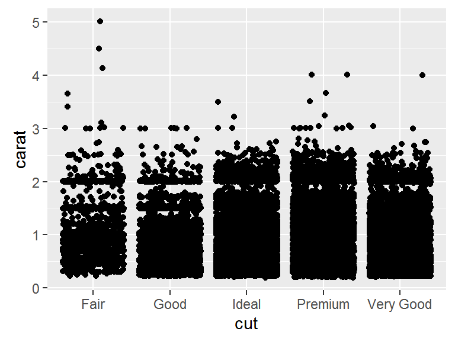

```r
ggplot(data, aes(x = cut, y = carat)) + geom_jitter()
```

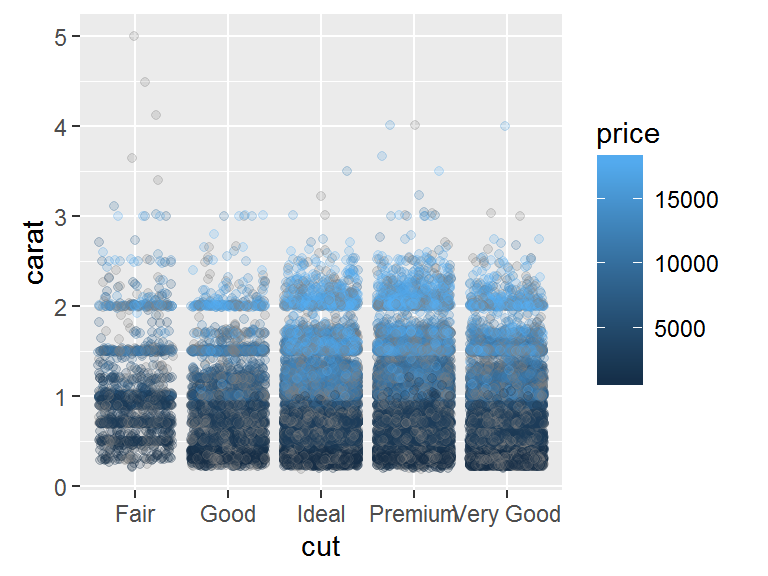

```r
ggplot(data, aes(x = cut, y = carat)) + geom_jitter(aes(color = price), alpha = 0.2)
```

# Bivariate Plot (3): Two Continuous Variables

- Point plot and with smooth line

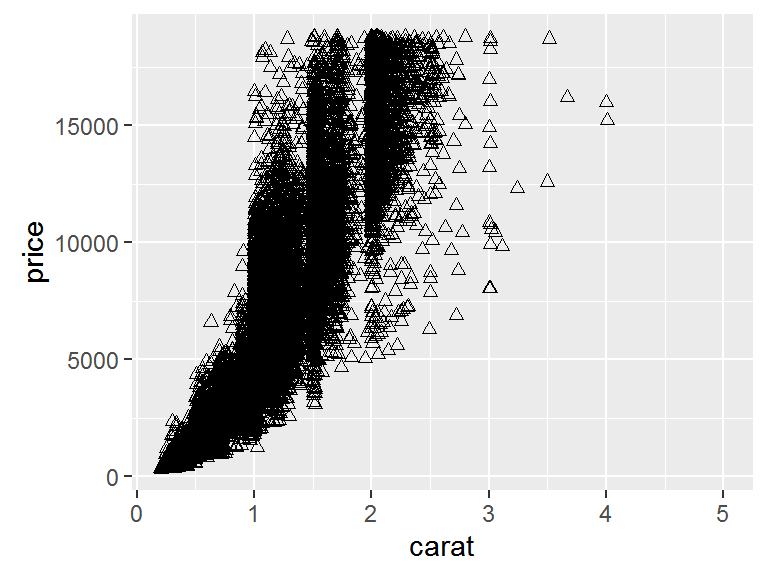

```r
ggplot(data, aes(x = carat, y = price)) + geom_point(size = 1.5, shape = 2)
```

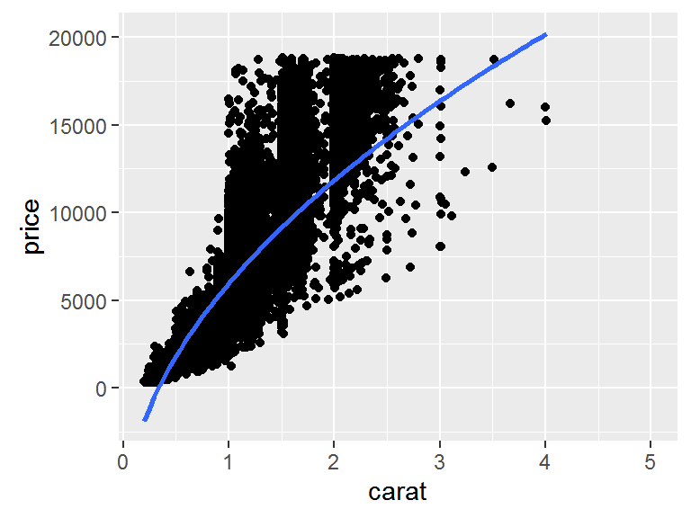

```r
ggplot(data, aes(x = carat, y = price)) + geom_point()+geom_smooth(method="lm",formula=y~sqrt(x))
```

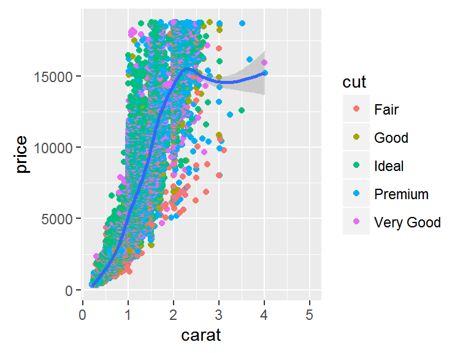

```r
ggplot(data, aes(x = carat, y = price)) + geom_point(aes(color = cut)) + geom_smooth()
```

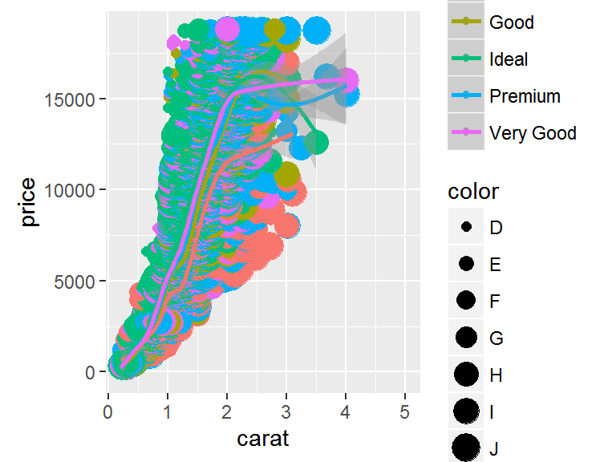

```r
ggplot(data, aes(x = carat, y = price, color = cut)) + geom_point(aes(size=color))+geom_smooth()
```

- 2-D heatmap, density, ellipses and marginal rug

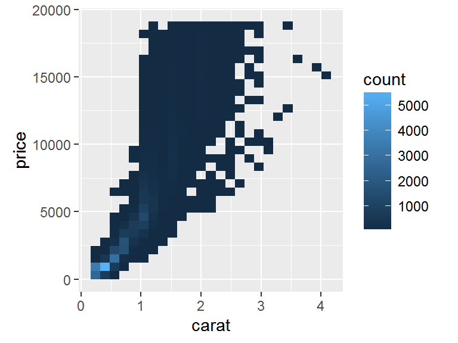

```r
ggplot(data, aes(x = carat, y = price)) + geom_bin2d()
```

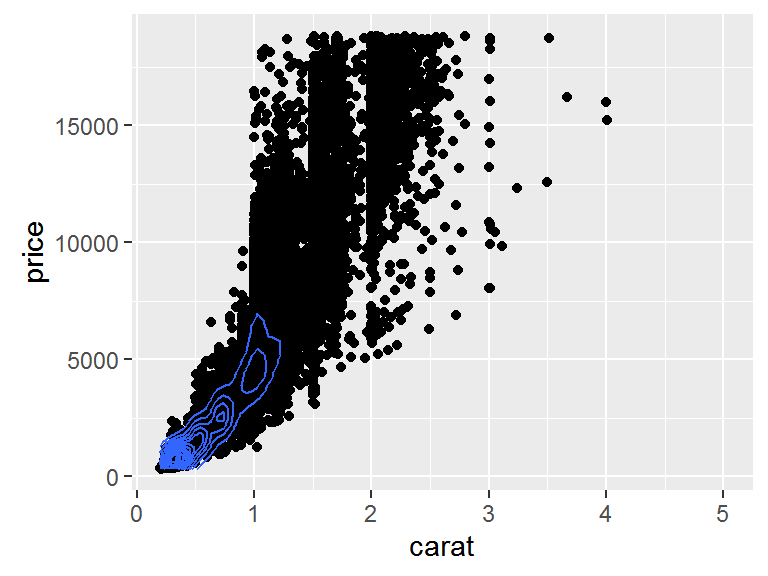

```r
ggplot(data, aes(x = carat, y = price)) + geom_point() + geom_density_2d()
```

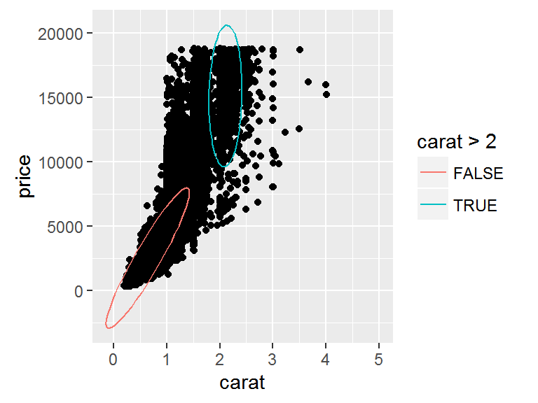

```r
ggplot(data, aes(x = carat, y = price)) + geom_point() + stat_ellipse(aes(color = carat > 2))
```

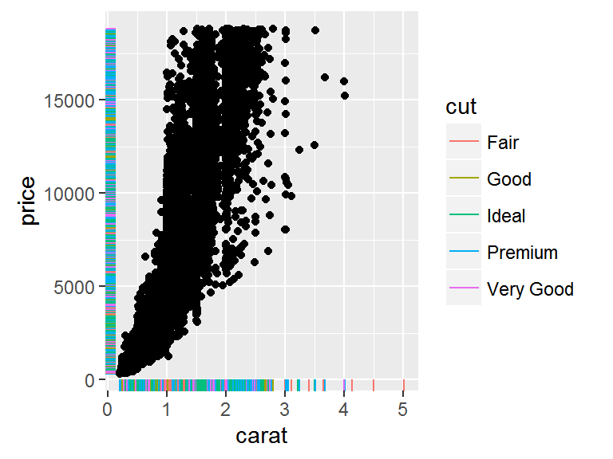

```r
ggplot(data, aes(x = carat, y = price)) + geom_point() + geom_rug(aes(color = cut))
```

# Trivariate Plot: 2D summary

- Summary z grouped by x and y

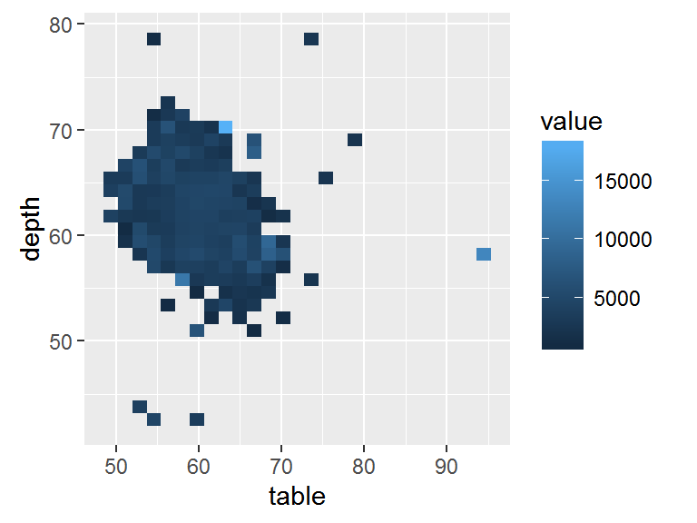

```r
ggplot(data, aes(x = table, y = depth, z = price)) + stat_summary_2d()
```

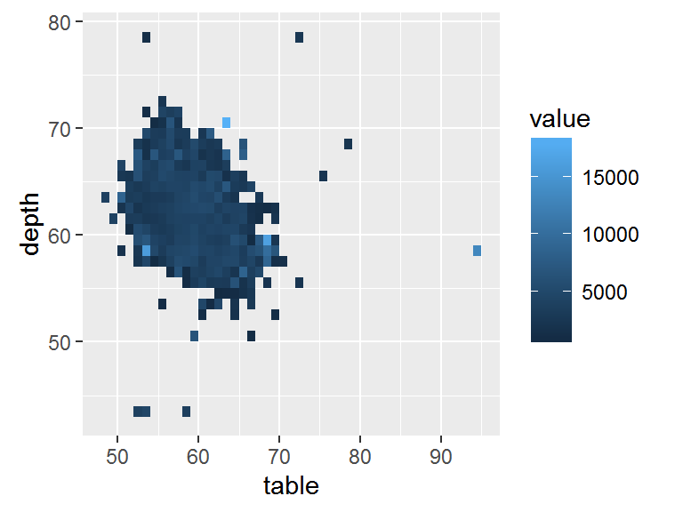

```r
ggplot(data, aes(x = table, y = depth, z = price)) + stat_summary_2d(binwidth = c(1, 1))
```

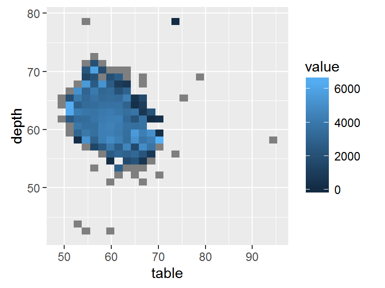

```r
ggplot(data, aes(x = table, y = depth, z = price)) + stat_summary_2d(fun = sd)
```

# 3.3 Layouts

# Axes, labels and themes

- Transform and flip coordinate axes

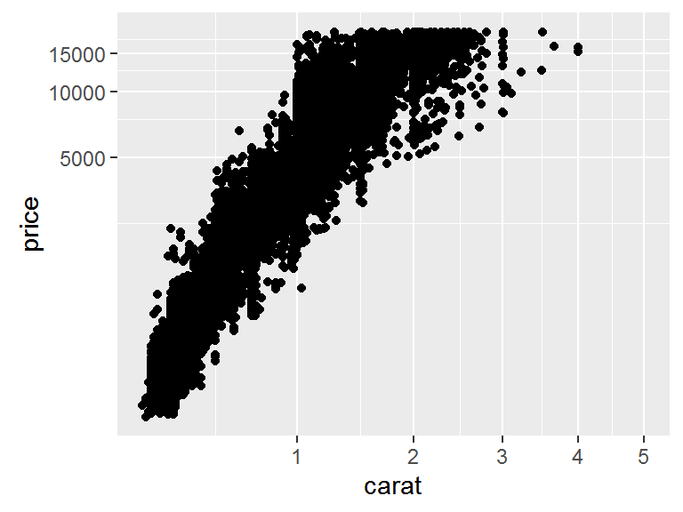

```r
p = ggplot(data, aes(x = carat, y = price)) + geom_point()
p + coord_trans(x="sqrt", y = "log10")
```

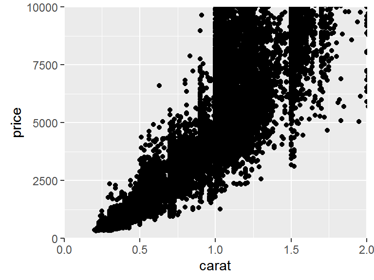

```r
p + coord_trans(limx=c(0, 2), limy = c(0, 10000))
```

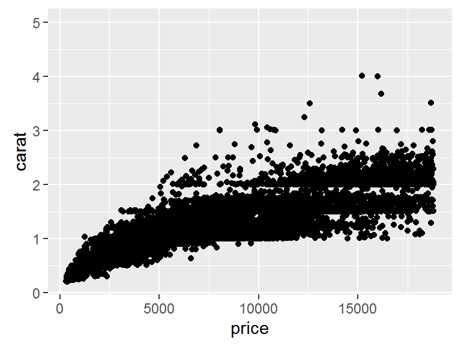

```r
p + coord_flip()
```

- Change title and axis labels, themes

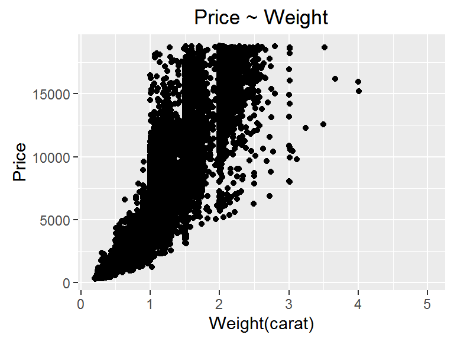

```r
p + labs(title = "Price ~ Weight", x = "Weight(carat)", y = "Price")
```

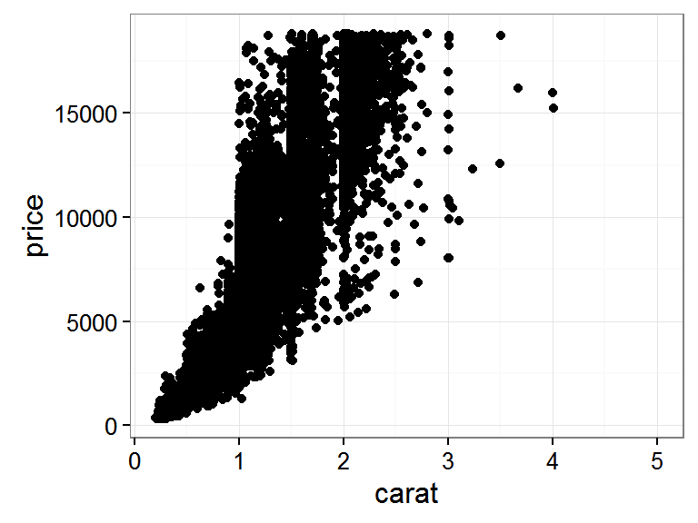

```r
p + theme_bw()
```

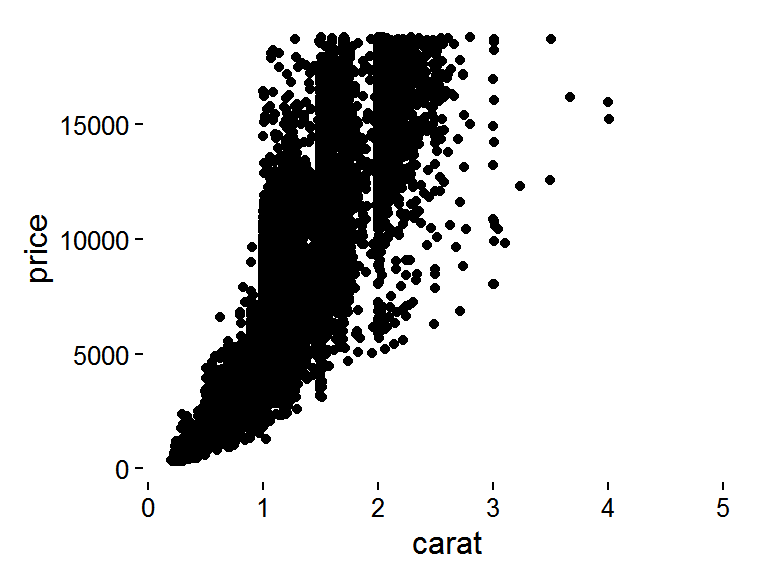

```r
p + theme_classic()
```

# Facet

- Make ggplot facet with facet_grid(facets = formula)

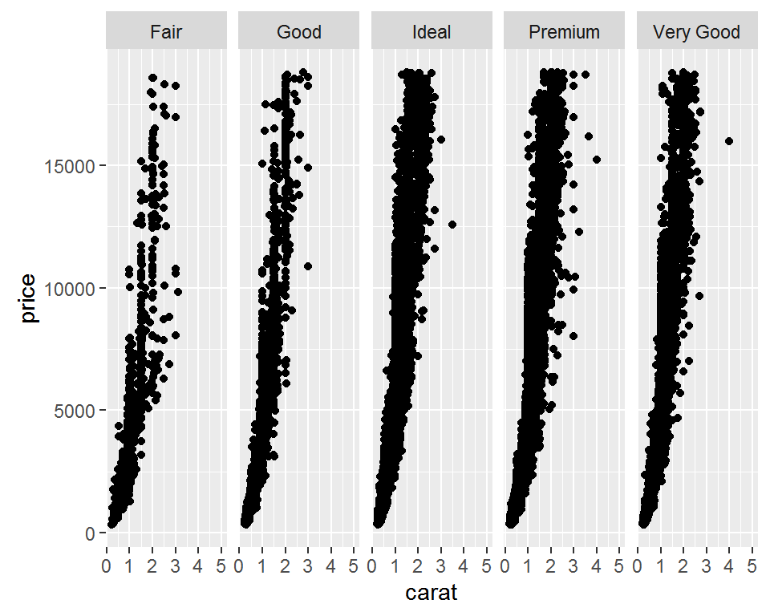

```r
p + facet_grid(. ~ cut)
```

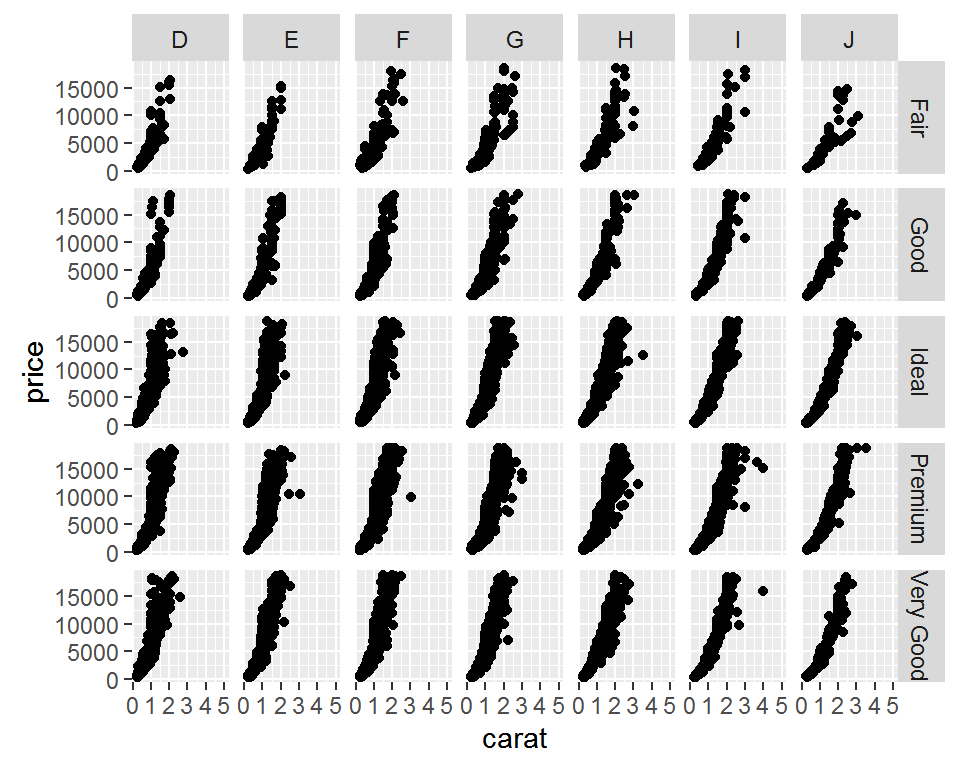

```r
p + facet_grid(cut ~ color)
```

# Scales and Margins in Facet

- We can adjust scales and margins in facet_grid()

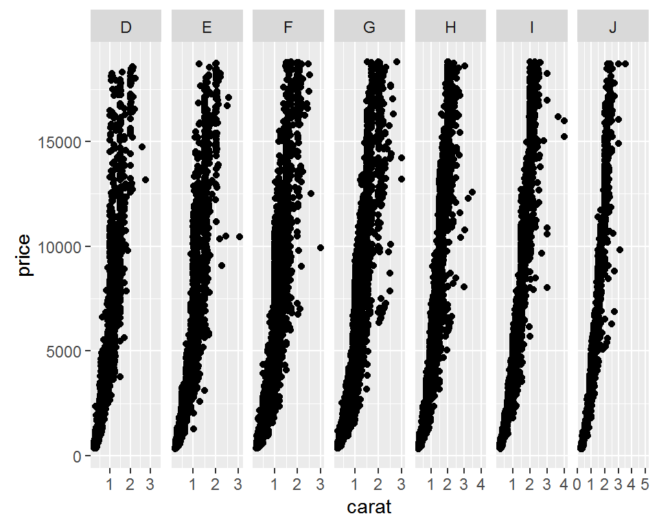

```r
p + facet_grid(. ~ color, scales = "free")
```

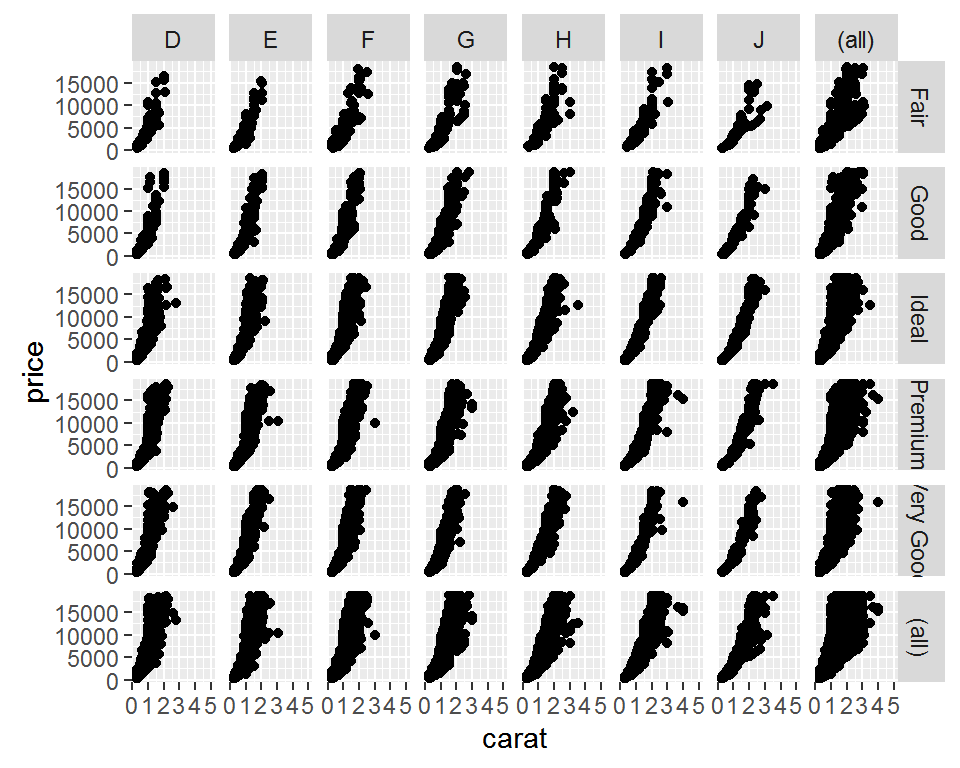

```r
p + facet_grid(cut ~ color, margins = TRUE)
```

# Lecture 4. Data Operation

# Preparation

- Download the [dataset](https://github.com/founderfan/Data-Open-Lecture) “Diamonds.csv”

# Our Goals

- Learn data operations simplified by [data.table](http://user014.stat.ucla.edu/files/tutorial_Matt.pdf)
- Learn how to summarize information of variables for cleaning
- Learn to design steps for data cleaning in data.table
- Learn how to use function/for/if and other structures in R working procedure